# MATH 2310 Lab 5

lolita kim

## Introduction

In this lab you will explore sampling distributions and the Central Limit theorem. You should read through and execute all of the code in the Sampling Distributions section. Then complete all parts of Problem 1 and Problem 2 before submitting the lab as an html file. Include text comments, at a minimum in all places where you see ‘Delete this text and type your answer’.

## Import Libraries

You should only need one new package, `tidymodels,` for this lab.

```r
#install.packages('tidymodels')
library(tidymodels)
library(tidyverse)
library(rstatix)
library(Stat2Data)
library(ggpubr)
library(GGally)
library(ISLR2)
```

## Sampling Distributions

This section contains code to show you some basic commands for creating a sampling distribution. You will use this code to answer the questions that follow.

### Generate a Sampling Distribution

This code assumes an underlying distribution is exponential with $\lambda = .5$ and generates $N=10,000$ samples each with $n=5$ elements and calculates the sample mean for each of the 10,000 samples. The results are stored in a vector called `sample_means.`

```r
#make this example reproducible
set.seed(0)

#define number of samples
N = 10000

#define the size of each sample
n = 5

#create empty vector of length N
sample_means = rep(NA, N)

#fill empty vector with means
for(i in 1:N){
  sample_means[i] = mean(rexp(n, rate=0.5)) # if you want to do a different underlying distribution replace rexp with one of the other known sample generators.
}

#view first six sample means
head(sample_means)
```

```
## [1] 1.5202303 1.7054374 3.4053419 2.3282841 0.6669561 3.2572223
```

### Draw a histogram

We have drawn histograms many times before, here is another where we create a histogram from the sample_means generated in the previous section. Note that, `breaks = 100` is appropriate since there are 10,000 values in `sample_means`.

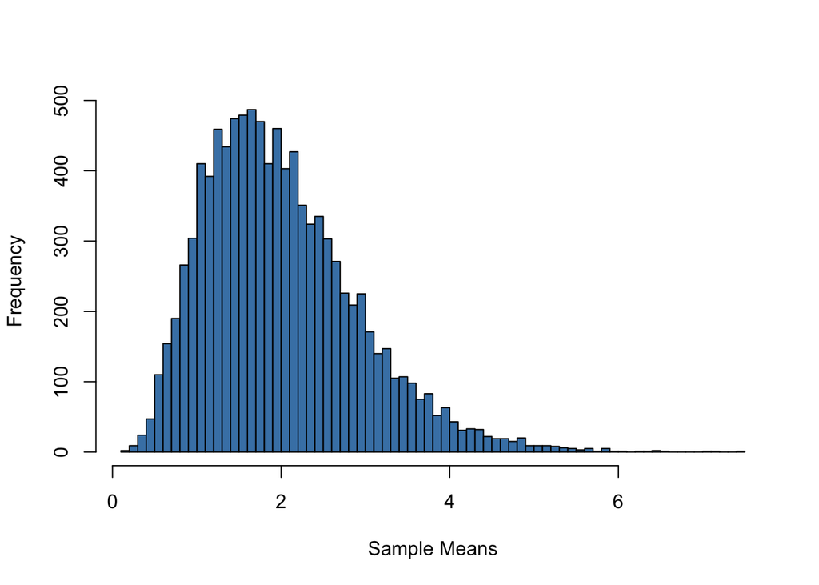

```r
#create histogram to visualize the sampling distribution
hist(sample_means, breaks =100, main = "", xlab = "Sample Means", col = "steelblue")
```

### Approximating parameters of our Sampling Distribution

Here we calculate the mean and the standard deviation *from the generated sampling distribution data*, although from class you have formulas of what the exact values should be based on the underlying distribution. The values from the generated data won’t match the theoretical values exactly (since we generated samples) but they should be very close since we took 10,000 sample means.

```r
#mean of sampling distribution
mean(sample_means)
```

```
## [1] 2.004274
```

```r
#standard deviation of sampling distribution
sd(sample_means)
```

```
## [1] 0.9111323
```

### Curves over histograms

This is just a refresher of how to draw a curve over a histogram. We did this in the second lab assignment.

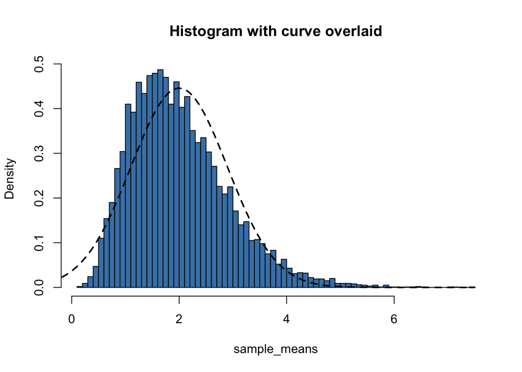

```r
# Make a histogram on the density scale
hist(sample_means, prob = TRUE, breaks=100, main= "Histogram with curve overlaid",col = "steelblue")

#Overlay a curve (note the add = TRUE)
curve(dnorm(x,2, 2/sqrt(n)), from =-2,col = 1, lty = 2, lwd = 2, add = TRUE)
```

## Problem 1

### Case when n = 1

- Generate 40000 sample means of a log normal distribution with $\mu=2$ and $\sigma = .5$ using samples of size $n=1$. ( Since $n=1$, this is actually not a sampling distribution its just a single sample from log-normal).

```r
#Code for generating sample means.
#make this example reproducible
set.seed(0)

#define number of samples
N = 40000

#define the size of each sample
n = 1

#create empty vector of length N
sample_means = rep(NA, N)

#fill empty vector with means
for(i in 1:N){
  sample_means[i] = mean(rlnorm(n, meanlog = 2, sdlog = .5)) # if you want to do a different underlying distribution replace rexp with one of the other known sample generators.
}
```

- Draw a histogram of the generated data.

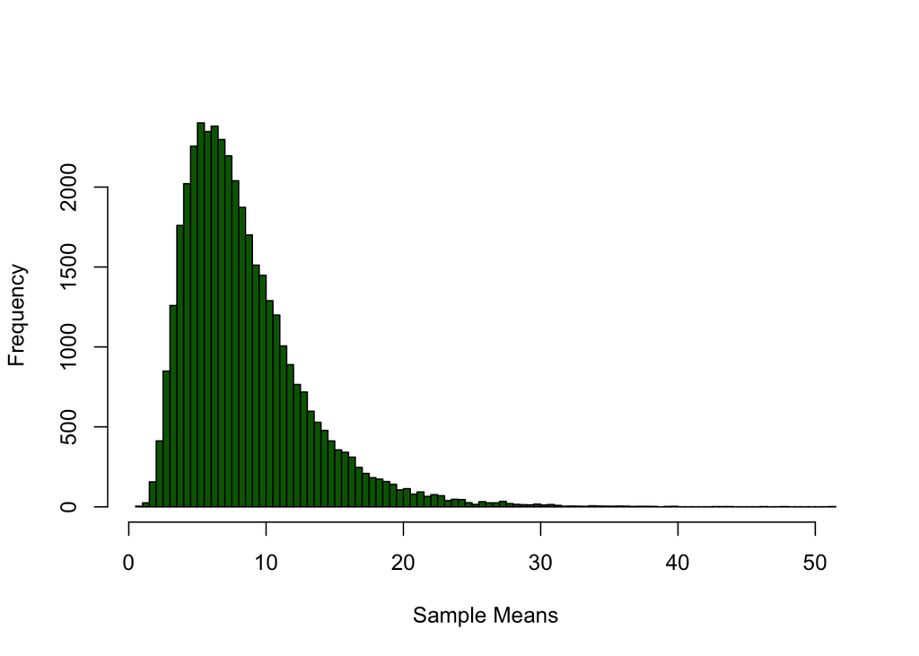

```r
# Make a histogram on the density scale - make sure the axes are labeled appropriately.
hist(sample_means, breaks =100, main = "", xlab = "Sample Means", col = "darkgreen")
```

- Describe in words what this histogram looks like (symmetry and modality).

This histogram is skewed-right.

- Is this distribution log-normal? Why or why not?

Yes, this is distribution log-normal because of 3 reasons: the range is positive values (from 0 to 50), it’s positively skewed, and its max point is not at 0 (in this case it is at 5 something).

- Is this distribution approximately normal? Why or why not?

No, this is not distribution approximately normal because the histogram shape is not symmetrical.

### Case when n = 5

- Generate 40000 sample means of a log normal distribution with $\mu=2$ and $\sigma = .5$ using samples of size $n=5$.

```r
#Code to generate sample means.
#make this example reproducible
set.seed(0)

#define number of samples
N = 40000

#define the size of each sample
n = 5

#create empty vector of length N
sample_means = rep(NA, N)

#fill empty vector with means
for(i in 1:N){
  sample_means[i] = mean(rlnorm(n, meanlog = 2, sdlog = .5)) # if you want to do a different underlying distribution replace rexp with one of the other known sample generators.
}
```

- Draw a histogram from the generated data.

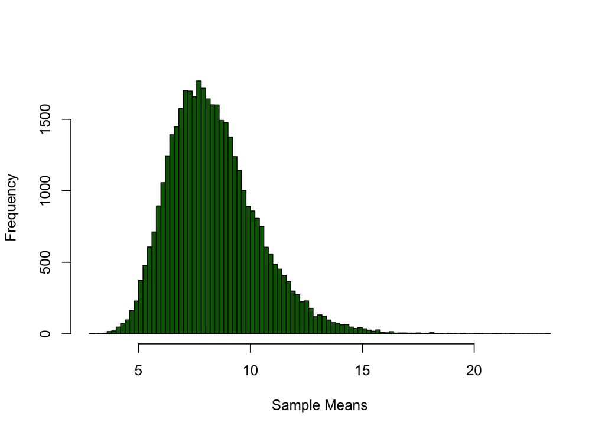

```r
# Make a histogram on the density scale, label axes appropriately and include a title for the plot.
hist(sample_means, breaks =100, main = "", xlab = "Sample Means", col = "darkgreen")
```

- Calculate the mean and the standard deviation from the generated data.

```r
#sample mean
mean(sample_means)
```

```
## [1] 8.365096
```

```r
#sample standard deviation
sd(sample_means)
```

```
## [1] 1.987994
```

- Recalling that the mean of a log-normal is $e^{\mu+\sigma^2/2}$ and the standard deviation of a log-normal is $\sqrt{\left(e^{\sigma^2}-1\right)e^{2\mu+\sigma^2}}$. Calculate, using the formulas derived in class what the mean and standard deviation of $\overline{x}$ should be for $n=5$. Does this agree with the values calculated from the generated data in the previous bullet?

```r
#Include calculations here
mu = 2
sd = .5
mu_ln = exp(mu+sd^2/2)
sd_ln = sqrt(exp(2*mu+sd^2/2)*(exp(sd^2)-1))
sd_ln_bar = sd_ln/sqrt(5)
mu_ln_bar = mu_ln

mu_ln_bar
```

```
## [1] 8.372897
```

```r
sd_ln_bar
```

```
## [1] 1.874675
```

Yes, this agree with the values calculated from the generated data in the previous bullet.

- Should the histogram for $n=5$ be log-normal shaped? Why or why not?

No, because we changed the sample size from 1 to 5.

- Should the histogram for $n=5$ be approximately normal shaped? Why or why not?

Yes, because as the sample size increases, the sampling distribution becomes more like normal distribution.

- If the histogram should be approximately normal, re-draw the histogram with the appropriate normal curve overlaid on top of the histogram

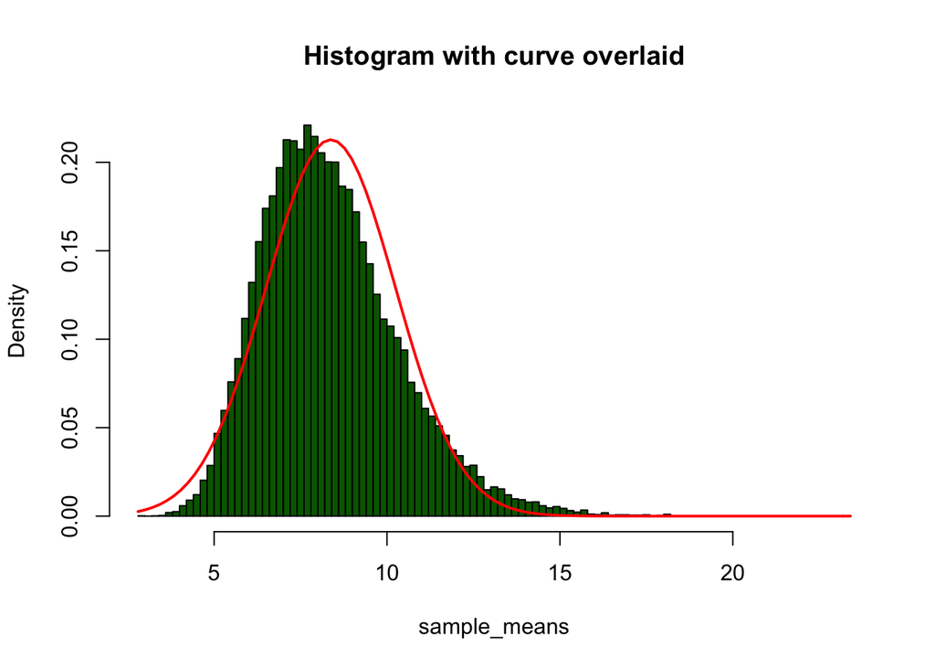

```r
# Make a histogram on the density scale with density curve overlaid if appropriate
# Make a histogram on the density scale
hist(sample_means, prob = TRUE, breaks=100, main= "Histogram with curve overlaid" ,col = "darkgreen")

#Overlay a curve (note the add = TRUE)
curve(dnorm(x, mu_ln_bar, sd_ln_bar), col="red", lwd=2, add=TRUE, yaxt="n")
```

### Case when n = 50

- Generate 40000 sample means of a log normal distribution with $\mu=2$ and $\sigma = .5$ using samples of size $n=50$.

```r
#Code for generating sample means.
#make this example reproducible
set.seed(0)

#define number of samples
N = 40000

#define the size of each sample
n = 50

#create empty vector of length N
sample_means = rep(NA, N)

#fill empty vector with means
for(i in 1:N){
  sample_means[i] = mean(rlnorm(n, meanlog = 2, sdlog = .5)) # if you want to do a different underlying distribution replace rexp with one of the other known sample generators.
}
```

- Draw a histogram from the generated data.

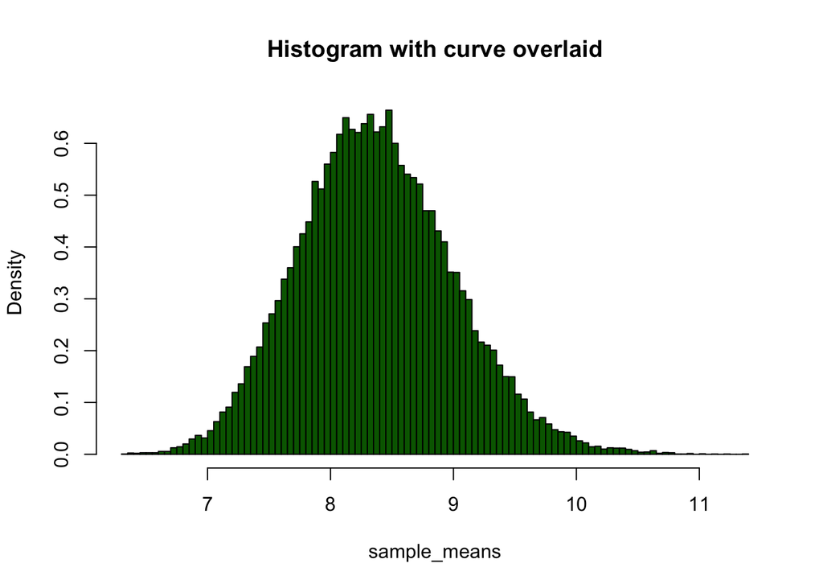

```r
# Make a histogram on the density scale label axes appropriately

hist(sample_means, prob = TRUE, breaks=100, main= "Histogram with curve overlaid" ,col = "darkgreen")
```

- Calculate the mean and the standard deviation from the generated data.

```r
#sample mean
mean(sample_means)
```

```
## [1] 8.372229
```

```r
#sample standard deviation
sd(sample_means)
```

```
## [1] 0.6272386
```

- Recalling that the mean of a log-normal is $e^{\mu+\sigma^2/2}$ and the standard deviation of a log-normal is $\sqrt{\left(e^{\sigma^2}-1\right)e^{\mu+\sigma^2/2}}$. Calculate, using the formulas derived in class what the mean and standard deviation of $\overline{x}$ should be for $n=50$. Does this agree with the values calculated from the generated data in the item above??

```r
#Include your calculations here
mu = 2
sd = .5
mu_ln = exp(mu+sd^2/2)
sd_ln = sqrt(exp(2*mu+sd^2/2)*(exp(sd^2)-1))
sd_ln_bar = sd_ln/sqrt(50)
mu_ln_bar = mu_ln

mu_ln_bar
```

```
## [1] 8.372897
```

```r
sd_ln_bar
```

```
## [1] 0.5928243
```

- In words describe the differences in the sampling distributions that you see between the case when $n=5$ and $n=50$.

The sampling distributions with the n=5 is less normal distribution than the one with n=50

- Should the histogram when $n=50$ be log-normal shaped? Why or why not?

No, because as mentioned before, the more the sample size increases, the more the sampling distribution becomes more like normal distribution.

- Should the histogram when $n=50$ be approximately normal shaped? Why or why not?

Yes totally, because we are averaging over more in x_bar value as the sample size gets bigger (from 5 to 50)

- If the histogram should be approximately normal, re-draw the histogram with the appropriate normal curve overlaid on top of the histogram.

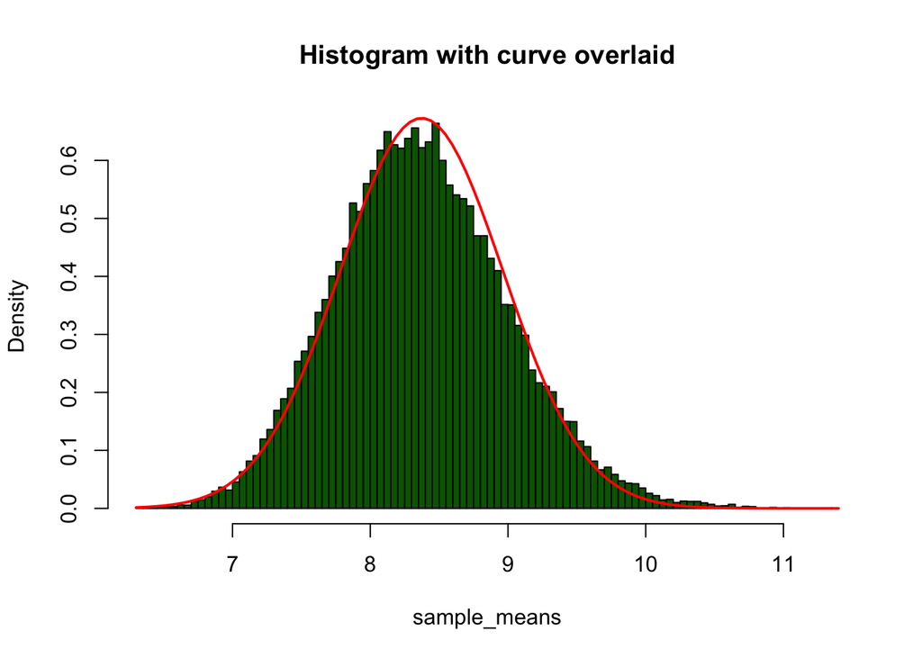

```r
# Make a histogram on the density scale with density curve overlaid if appropriate
hist(sample_means, prob = TRUE, breaks=100, main= "Histogram with curve overlaid" ,col = "darkgreen")

#Overlay a curve (note the add = TRUE)
curve(dnorm(x, mu_ln_bar, sd_ln_bar), col="red", lwd=2, add=TRUE, yaxt="n")
```

## Problem 2

Suppose the number of visitors to a particular website is known to be very regular and described by a Poisson Process with an average of 2500 visitors per minute.

- You plan to do an experiment where you calculate the number of visitors each minute during the day. Then you average all the by-minute values creating a mean for the day (there are 1440 minutes in a day). Use the Central Limit Theorem and the built in normal distribution functions to determine the range of values one would expect the daily average to be in 95% of the time?

```r
lambda = 2500
mean_bar= lambda
sd_bar= sqrt(lambda)/sqrt(1440)
left_endpoint = mean_bar - 2*sd_bar
right_endpoint = mean_bar + 2*sd_bar

left_endpoint
```

```
## [1] 2497.365
```

```r
right_endpoint
```

```
## [1] 2502.635
```

The range is [2497.365, 2502.635]

- Suppose you do your experiment, as described above, and you observe that the average of the number per minute on the the particular day is 2510 visitors. Would you be surprised by this outcome? Explain your answer.

- Suppose instead of collecting the data every minute for a full day you only collect the data every minute for an *hour* and then calculate the average of the by-minute-values over the 60 minutes in that hour. You observe that the resulting average is 2510. Would this be in the range of values you’d expect to see 95% of the time if you repeated this experiment over and over?

```r
#Include calculations
lambda = 2510
mean_bar= lambda
sd_bar= sqrt(lambda)/sqrt(60)
left_endpoint = mean_bar - 2*sd_bar
right_endpoint = mean_bar + 2*sd_bar

left_endpoint
```

```
## [1] 2497.064
```

```r
right_endpoint
```

```
## [1] 2522.936
```

Yes, this will in the range of values you’d expect to see 95% of the time if you repeated this experiment over and over.